# LINEAR_REG_Q1

```r
library(tidyverse)
```

```r
library(cowplot)
theme_set(theme_cowplot())
options(scipen=999)
```

```r
movies_linear_reg = read_csv("/Users/admin/Desktop/320 DATA/movies_linear_reg.csv")
head(movies_linear_reg)
```

```
## # A tibble: 6 x 49
##   budget revenue runtime vote_average vote_count popularity release_date
##    <dbl>   <dbl>   <dbl>        <dbl>      <dbl>      <dbl> <date>
## 1 4.00e6  4.30e6      98          6.5        530       22.9 1995-12-09
## 2 1.10e7  7.75e8     121          8.1       6624      126.  1977-05-25
## 3 9.40e7  9.40e8     100          7.6       6122       85.7 2003-05-30
## 4 5.50e7  6.78e8     142          8.2       7927      138.  1994-07-06
## 5 1.50e7  3.56e8     122          7.9       3313       80.9 1999-09-15
## 6 1.28e7  4.00e7     140          7.6        377       22.0 2000-05-17
## # … with 42 more variables: length_of_title <dbl>,
## #   total_spoken_languages <dbl>, Crime <dbl>, Adventure <dbl>,
## #   Animation <dbl>, Comedy <dbl>, Drama <dbl>, Action <dbl>,
## #   Western <dbl>, Science_Fiction <dbl>, Mystery <dbl>, Thriller <dbl>,
## #   Romance <dbl>, Fantasy <dbl>, Horror <dbl>, War <dbl>, Family <dbl>,
## #   Documentary <dbl>, Music <dbl>, History <dbl>, TV_Movie <dbl>,
## #   Foreign <dbl>, Universal_Pictures <dbl>, Warner_Bros <dbl>,
## #   Fox_Film_Corp <dbl>, MGM <dbl>, Columbia <dbl>, Lionsgate <dbl>,
## #   US <dbl>, UK <dbl>, DE <dbl>, FR <dbl>, CA <dbl>,
## #   Steven_Spielberg <dbl>, Woody_Allen <dbl>, Clint_Eastwood <dbl>,
## #   Martin_Scorsese <dbl>, Robert_De_Niro <dbl>, Bruce_Willis <dbl>,
## #   Matt_Damon <dbl>, Nicolas_Cage <dbl>, Samuel_L_Jackson <dbl>
```

The data we will use for linear regression (Question 1) is above. There are numeric variables, genre dummy variables, the top 6 production companies dummy variables, top 5 country dummy variables, top 4 director dummy variables, and top 5 actor dummy variables, for a total of 49 variables. The top 5s were chosen based on their frequency, i.e they were chosen because they had at least 30 instances in our dataset. Companies/countrys/actors/directors with fewer than 30 were ignored.

We are trying to predict vote_average by all the other variables.

```r
get.RMSE = function(resids){
  resids_squared = resids^2
  resids_squared_summed = sum(resids_squared)
  resids_squared_summed_div_by_n = resids_squared_summed / length(resids)
  resids_squared_summed_div_by_n_rooted = sqrt(resids_squared_summed_div_by_n)
  return(resids_squared_summed_div_by_n_rooted)
}
```

We will use the RMSE function above as a way of evaluating the predictive power of the model.

```r
# First a simple, full model

model_1 = lm(vote_average ~ ., data=movies_linear_reg)
summary(model_1)
```

```
##
## Call:
## lm(formula = vote_average ~ ., data = movies_linear_reg)
##
## Residuals:
##     Min      1Q  Median      3Q     Max
## -6.6820 -0.3551  0.1075  0.5165  5.4436
##
## Coefficients:
##                                Estimate       Std. Error t value
## (Intercept)             5.3494612129611  0.1112789513289  48.073
## budget                  0.0000000003295  0.0000000001814   1.816
## revenue                -0.0000000007947  0.0000000001408  -5.645
## runtime                 0.0091542157274  0.0007468152850  12.258
## vote_count              0.0003248095377  0.0000203867031  15.932
## popularity              0.0029504219054  0.0006512856550   4.530
## release_date           -0.0000536317384  0.0000031086723 -17.252
## length_of_title        -0.0030250533769  0.0016122055572  -1.876
## total_spoken_languages  0.0384206730705  0.0149331022611   2.573
## Crime                   0.1821357420039  0.0423428696860   4.301
## Adventure              -0.0353843695502  0.0431002941347  -0.821
## Animation               0.6145943278743  0.0707953353287   8.681
## Comedy                  0.0619272262010  0.0357154167398   1.734
## Drama                   0.4717265083880  0.0348451773255  13.538
## Action                 -0.2065831879561  0.0372870446693  -5.540
## Western                -0.0373391973748  0.1259684745359  -0.296
## Science_Fiction        -0.1025699473034  0.0507153956827  -2.022
## Mystery                 0.0655802369301  0.0573840970636   1.143
## Thriller               -0.0238450327658  0.0381644785858  -0.625
## Romance                 0.0011993120775  0.0394614794953   0.030
## Fantasy                -0.0304529714296  0.0529092283370  -0.576
## Horror                 -0.1292157132595  0.0501827782493  -2.575
## War                     0.1157833248919  0.0929147330723   1.246
## Family                 -0.1023381294972  0.0536554455119  -1.907
## Documentary             1.0603578286582  0.1075473477351   9.859
## Music                   0.1919756003751  0.0759258787266   2.528
## History                -0.0020393451983  0.0761684396794  -0.027
## TV_Movie               -0.6656689239853  0.3981997949801  -1.672
## Foreign                 0.1142232654639  0.1779006791404   0.642
## Universal_Pictures      0.0198138885425  0.0536988553867   0.369
```

[output cut: 61 more lines]

```
## Woody_Allen                        0.003246 **
## Clint_Eastwood                     0.060523 .
## Martin_Scorsese                    0.908715
## Robert_De_Niro                     0.839940
## Bruce_Willis                       0.805046
## Matt_Damon                         0.800681
## Nicolas_Cage                       0.175015
## Samuel_L_Jackson                   0.652871
## ---
## Signif. codes:  0 '***' 0.001 '**' 0.01 '*' 0.05 '.' 0.1 ' ' 1
##
## Residual standard error: 0.8879 on 4594 degrees of freedom
##   (60 observations deleted due to missingness)
## Multiple R-squared:  0.3358, Adjusted R-squared:  0.3288
## F-statistic: 48.38 on 48 and 4594 DF,  p-value: < 0.00000000000000022
```

```r
RMSE1 = get.RMSE(model_1$residuals)
RMSE1
```

```
## [1] 0.8832103
```

```r
ARS1 = summary(model_1)$adj.r.squared
ARS1
```

```
## [1] 0.3288322
```

Adj. R-Sq is 0.3288, RMSE = 0.8832.

The first thing we notice is that the top 5 actors by freqency, Robert De Niro, Bruce Willis, Matt Damon, Nicolas Cage, and Samuel L Jackson are all insignificant. Therefore, we will drop top 5 actors from the regression.

```r
movies_linear_reg_2 = movies_linear_reg %>% select(-Robert_De_Niro, -Bruce_Willis, -Matt_Damon, -Nicolas_Cage, -Samuel_L_Jackson)
```

```r
model_2 = lm(vote_average ~ ., data=movies_linear_reg_2)
summary(model_2)
```

```
##
## Call:
## lm(formula = vote_average ~ ., data = movies_linear_reg_2)
##
## Residuals:
##     Min      1Q  Median      3Q     Max
## -6.6823 -0.3573  0.1141  0.5307  5.5941
##
## Coefficients:
##                                Estimate       Std. Error t value
## (Intercept)             5.1103798304359  0.1129683823965  45.237
## budget                  0.0000000003629  0.0000000001922   1.888
## revenue                -0.0000000008248  0.0000000001494  -5.520
## runtime                 0.0102417990638  0.0007636678640  13.411
## vote_count              0.0003217867295  0.0000216095153  14.891
## popularity              0.0030986112629  0.0006914240016   4.481
## release_date           -0.0000541913868  0.0000032906406 -16.468
## length_of_title        -0.0044051499715  0.0016924313852  -2.603
## total_spoken_languages  0.0470540965523  0.0157818429247   2.982
## Crime                   0.1882003051354  0.0446860638642   4.212
## Adventure              -0.0036938413650  0.0455850559224  -0.081
## Animation               0.6757607490687  0.0747725724258   9.038
## Comedy                  0.1264334247698  0.0373647279787   3.384
## Drama                   0.5166159546391  0.0366216383102  14.107
## Action                 -0.1881884805972  0.0393634651416  -4.781
## Western                 0.0108361806903  0.1334645304263   0.081
## Science_Fiction        -0.0667600787690  0.0536670618137  -1.244
## Mystery                 0.0818612318000  0.0606898041638   1.349
## Thriller                0.0155277772252  0.0403025996856   0.385
## Romance                 0.0267323572980  0.0417863590950   0.640
## Fantasy                 0.0000771979490  0.0559966789121   0.001
## Horror                 -0.0723273270949  0.0527503547156  -1.371
## War                     0.1280400766609  0.0985770533179   1.299
## Family                 -0.0857928578006  0.0564671468156  -1.519
## Documentary             0.9597954201832  0.1011713558550   9.487
## Music                   0.2003468317683  0.0799865697835   2.505
## History                -0.0055826516864  0.0804931295620  -0.069
## TV_Movie               -0.6072217684778  0.4229960434235  -1.436
## Foreign                 0.2600719976958  0.1854484919332   1.402
## Universal_Pictures      0.0177086376446  0.0569578885331   0.311
```

[output cut: 51 more lines]

```
## UK                             0.0000447634 ***
## DE                                 0.634863
## FR                                 0.008518 **
## CA                                 0.426410
## Steven_Spielberg                   0.408874
## Woody_Allen                        0.004931 **
## Clint_Eastwood                     0.066173 .
## Martin_Scorsese                    0.930387
## ---
## Signif. codes:  0 '***' 0.001 '**' 0.01 '*' 0.05 '.' 0.1 ' ' 1
##
## Residual standard error: 0.9433 on 4656 degrees of freedom
##   (3 observations deleted due to missingness)
## Multiple R-squared:  0.3226, Adjusted R-squared:  0.3163
## F-statistic: 51.56 on 43 and 4656 DF,  p-value: < 0.00000000000000022
```

```r
RMSE2 = get.RMSE(model_2$residuals)
RMSE2
```

```
## [1] 0.9388753
```

```r
ARS2 = summary(model_2)$adj.r.squared
ARS2
```

```
## [1] 0.3163336
```

Adj. R-Squared = .316, RMSE = 0.9389.

Next, of our top 4 Directors, Martin_Scorsese and Steven_Spielberg have large p-values. Thus, we will remove them from the regression. The R-sq and RMSE became worse, but that is expected since fewer variables will always cause that, regardless of significance.

```r
movies_linear_reg_3 = movies_linear_reg_2 %>% select(-Martin_Scorsese, -Steven_Spielberg)
```

```r
model_3 = lm(vote_average ~ ., data=movies_linear_reg_3)
summary(model_3)
```

```
##
## Call:
## lm(formula = vote_average ~ ., data = movies_linear_reg_3)
##
## Residuals:
##     Min      1Q  Median      3Q     Max
## -6.6827 -0.3579  0.1143  0.5303  5.5954
##
## Coefficients:
##                                Estimate       Std. Error t value
## (Intercept)             5.1085097485757  0.1128755819986  45.258
## budget                  0.0000000003537  0.0000000001917   1.845
## revenue                -0.0000000008155  0.0000000001488  -5.479
## runtime                 0.0102565832092  0.0007610908035  13.476
## vote_count              0.0003218187347  0.0000215575422  14.928
## popularity              0.0030874968451  0.0006910622895   4.468
## release_date           -0.0000542496316  0.0000032860353 -16.509
## length_of_title        -0.0043782183912  0.0016918841037  -2.588
## total_spoken_languages  0.0479484276852  0.0157423556916   3.046
## Crime                   0.1876401776103  0.0446458842685   4.203
## Adventure              -0.0022848830370  0.0455460687319  -0.050
## Animation               0.6746933693999  0.0747510591938   9.026
## Comedy                  0.1261622335846  0.0373401286755   3.379
## Drama                   0.5166797007284  0.0366161687044  14.111
## Action                 -0.1892052952085  0.0392933565685  -4.815
## Western                 0.0097045645337  0.1334052523794   0.073
## Science_Fiction        -0.0651724269622  0.0536152128491  -1.216
## Mystery                 0.0820047600588  0.0606706308712   1.352
## Thriller                0.0152522237066  0.0402858656268   0.379
## Romance                 0.0257187378266  0.0417463789882   0.616
## Fantasy                -0.0003569794926  0.0559749169162  -0.006
## Horror                 -0.0722502291100  0.0527407273155  -1.370
## War                     0.1300521486841  0.0985097227731   1.320
## Family                 -0.0861393416107  0.0564575121950  -1.526
## Documentary             0.9592330684693  0.1011064225282   9.487
## Music                   0.1995023333608  0.0799410149146   2.496
## History                -0.0029097317002  0.0804049673192  -0.036
## TV_Movie               -0.6062689822928  0.4229349470562  -1.433
## Foreign                 0.2600769768798  0.1854209709272   1.403
## Universal_Pictures      0.0198006283595  0.0568817619666   0.348
```

[output cut: 47 more lines]

```
## Lionsgate                          0.857851
## US                                 0.807083
## UK                             0.0000507958 ***
## DE                                 0.642904
## FR                                 0.008600 **
## CA                                 0.427103
## Woody_Allen                        0.004938 **
## Clint_Eastwood                     0.067520 .
## ---
## Signif. codes:  0 '***' 0.001 '**' 0.01 '*' 0.05 '.' 0.1 ' ' 1
##
## Residual standard error: 0.9432 on 4658 degrees of freedom
##   (3 observations deleted due to missingness)
## Multiple R-squared:  0.3225, Adjusted R-squared:  0.3165
## F-statistic: 54.08 on 41 and 4658 DF,  p-value: < 0.00000000000000022
```

```r
RMSE3 = get.RMSE(model_3$residuals)
RMSE3
```

```
## [1] 0.9389451
```

```r
ARS3 = summary(model_3)$adj.r.squared
ARS3
```

```
## [1] 0.3165256
```

Adj. R-squared = 0.3165, RMSE = 0.9389.

Next, we will remove insignificant production countries, which are: US, DE, and CA.

```r
movies_linear_reg_4 = movies_linear_reg_3 %>% select(-US, -DE, -CA)
```

```r
model_4 = lm(vote_average ~ ., data=movies_linear_reg_4)
summary(model_4)
```

```
##
## Call:
## lm(formula = vote_average ~ ., data = movies_linear_reg_4)
##
## Residuals:
##     Min      1Q  Median      3Q     Max
## -6.6775 -0.3551  0.1161  0.5311  5.5892
##
## Coefficients:
##                                Estimate       Std. Error t value
## (Intercept)             5.1007360267252  0.1077244839534  47.350
## budget                  0.0000000003598  0.0000000001912   1.882
## revenue                -0.0000000008183  0.0000000001487  -5.502
## runtime                 0.0102445427431  0.0007594567184  13.489
## vote_count              0.0003211743623  0.0000215254479  14.921
## popularity              0.0030851412266  0.0006898915648   4.472
## release_date           -0.0000540064970  0.0000032739459 -16.496
## length_of_title        -0.0043710511421  0.0016911383404  -2.585
## total_spoken_languages  0.0488022837717  0.0156608878747   3.116
## Crime                   0.1876896631089  0.0446132315215   4.207
## Adventure              -0.0025158086994  0.0455281951607  -0.055
## Animation               0.6743889082754  0.0746907846922   9.029
## Comedy                  0.1252019765982  0.0372386699512   3.362
## Drama                   0.5172329391892  0.0365945259036  14.134
## Action                 -0.1884185470291  0.0392686826912  -4.798
## Western                 0.0109168910974  0.1333121783184   0.082
## Science_Fiction        -0.0622689248010  0.0535134325612  -1.164
## Mystery                 0.0854069772469  0.0605197161102   1.411
## Thriller                0.0145822884111  0.0402141508755   0.363
## Romance                 0.0249800534907  0.0417260904664   0.599
## Fantasy                 0.0001522750293  0.0559377096882   0.003
## Horror                 -0.0694867049143  0.0526249803044  -1.320
## War                     0.1320142104931  0.0984543937842   1.341
## Family                 -0.0866872527552  0.0564077355060  -1.537
## Documentary             0.9570230187510  0.1010354839721   9.472
## Music                   0.1978177178175  0.0798572704829   2.477
## History                -0.0008485465909  0.0802632165990  -0.011
## TV_Movie               -0.6118449011490  0.4228043589935  -1.447
## Foreign                 0.2693902985558  0.1837100659952   1.466
## Universal_Pictures      0.0192591430025  0.0566274681477   0.340
```

[output cut: 41 more lines]

```
## Fox_Film_Corp                       0.06693 .
## MGM                                 0.27678
## Columbia                            0.56993
## Lionsgate                           0.83285
## UK                             0.0000159102 ***
## FR                                  0.00415 **
## Woody_Allen                         0.00514 **
## Clint_Eastwood                      0.06978 .
## ---
## Signif. codes:  0 '***' 0.001 '**' 0.01 '*' 0.05 '.' 0.1 ' ' 1
##
## Residual standard error: 0.943 on 4661 degrees of freedom
##   (3 observations deleted due to missingness)
## Multiple R-squared:  0.3223, Adjusted R-squared:  0.3168
## F-statistic: 58.35 on 38 and 4661 DF,  p-value: < 0.00000000000000022
```

```r
RMSE4 = get.RMSE(model_4$residuals)
RMSE4
```

```
## [1] 0.9390444
```

```r
ARS4 = summary(model_4)$adj.r.squared
ARS4
```

```
## [1] 0.3168211
```

Adj. R-squared = 0.317, RMSE = 0.939.

```r
movies_linear_reg_5 = movies_linear_reg_4 %>% select(-Lionsgate, -Columbia, -MGM, -Universal_Pictures)
```

```r
model_5 = lm(vote_average ~ ., data=movies_linear_reg_5)
summary(model_5)
```

```
##
## Call:
## lm(formula = vote_average ~ ., data = movies_linear_reg_5)
##
## Residuals:
##     Min      1Q  Median      3Q     Max
## -6.6784 -0.3593  0.1155  0.5320  5.5925
##
## Coefficients:
##                                Estimate       Std. Error t value
## (Intercept)             5.0890175297561  0.1072272209554  47.460
## budget                  0.0000000003544  0.0000000001911   1.855
## revenue                -0.0000000008164  0.0000000001486  -5.495
## runtime                 0.0102563703121  0.0007578488407  13.534
## vote_count              0.0003215799886  0.0000215087772  14.951
## popularity              0.0030844596606  0.0006887840166   4.478
## release_date           -0.0000534048645  0.0000032237153 -16.566
## length_of_title        -0.0043527730946  0.0016889843016  -2.577
## total_spoken_languages  0.0491044048159  0.0156445595959   3.139
## Crime                   0.1877557426257  0.0445966381580   4.210
## Adventure              -0.0033705172670  0.0455044180835  -0.074
## Animation               0.6758410616083  0.0745743555973   9.063
## Comedy                  0.1258723709846  0.0371703296978   3.386
## Drama                   0.5173680264678  0.0365010066156  14.174
## Action                 -0.1884498475268  0.0392492345718  -4.801
## Western                 0.0133955348480  0.1332082012673   0.101
## Science_Fiction        -0.0621138777637  0.0534910472653  -1.161
## Mystery                 0.0848393432722  0.0604751781490   1.403
## Thriller                0.0149301917101  0.0401924986908   0.371
## Romance                 0.0237874584429  0.0416830363925   0.571
## Fantasy                -0.0002554335134  0.0558974131402  -0.005
## Horror                 -0.0688068538102  0.0525924173819  -1.308
## War                     0.1250305938594  0.0982696035639   1.272
## Family                 -0.0855954080911  0.0563720017882  -1.518
## Documentary             0.9593125127779  0.1009519220882   9.503
## Music                   0.1940091532370  0.0797686887887   2.432
## History                -0.0002369967975  0.0802375663175  -0.003
## TV_Movie               -0.6108631813917  0.4226835090606  -1.445
## Foreign                 0.2713001787889  0.1836182506954   1.478
## Warner_Bros            -0.1580263604525  0.0628400412051  -2.515
```

[output cut: 33 more lines]

```
## TV_Movie                           0.148468
## Foreign                            0.139603
## Warner_Bros                        0.011945 *
## Fox_Film_Corp                      0.070596 .
## UK                             0.0000129735 ***
## FR                                 0.003658 **
## Woody_Allen                        0.004850 **
## Clint_Eastwood                     0.067158 .
## ---
## Signif. codes:  0 '***' 0.001 '**' 0.01 '*' 0.05 '.' 0.1 ' ' 1
##
## Residual standard error: 0.9427 on 4665 degrees of freedom
##   (3 observations deleted due to missingness)
## Multiple R-squared:  0.3221, Adjusted R-squared:  0.3172
## F-statistic: 65.19 on 34 and 4665 DF,  p-value: < 0.00000000000000022
```

```r
RMSE5 = get.RMSE(model_5$residuals)
RMSE5
```

```
## [1] 0.9392135
```

```r
ARS5 = summary(model_5)$adj.r.squared
ARS5
```

```
## [1] 0.317161
```

Adj. R-sq = 0.317, RMSE = 0.939.

Next, we will remove genres which are insignificant. These are: Foreign, TV_Movie, Family, War, History, Horror, Fantasy, Romance, Thriller, Mystery, Sci Fi, Western, and Adventure.

```r
movies_linear_reg_6 = movies_linear_reg_5 %>% select(-Foreign, -TV_Movie, -Family, -War, -History, -Horror, -Fantasy, -Romance, -Thriller, -Mystery, -Science_Fiction, -Western, -Adventure)
```

```r
model_6 = lm(vote_average ~ ., data=movies_linear_reg_6)
summary(model_6)
```

```
##
## Call:
## lm(formula = vote_average ~ ., data = movies_linear_reg_6)
##
## Residuals:
##     Min      1Q  Median      3Q     Max
## -6.7123 -0.3592  0.1166  0.5354  5.6400
##
## Coefficients:
##                                Estimate       Std. Error t value
## (Intercept)             5.0329293998724  0.0966048902965  52.098
## budget                  0.0000000003574  0.0000000001902   1.879
## revenue                -0.0000000008170  0.0000000001471  -5.556
## runtime                 0.0105962278648  0.0007281309880  14.553
## vote_count              0.0003182072072  0.0000212907223  14.946
## popularity              0.0030666981939  0.0006874009797   4.461
## release_date           -0.0000533540857  0.0000031890662 -16.730
## length_of_title        -0.0045697952361  0.0016684657958  -2.739
## total_spoken_languages  0.0531173998922  0.0154886664559   3.429
## Crime                   0.2011445875206  0.0418460794837   4.807
## Animation               0.6488133119868  0.0686625939017   9.449
## Comedy                  0.1323773501534  0.0314363997167   4.211
## Drama                   0.5405221200694  0.0319321990633  16.927
## Action                 -0.1875654518809  0.0356909810738  -5.255
## Documentary             0.9813266456804  0.0962693502405  10.194
## Music                   0.1891008005674  0.0788610757148   2.398
## Warner_Bros            -0.1583328287531  0.0626627888000  -2.527
## Fox_Film_Corp          -0.1272009072759  0.0664617745460  -1.914
## UK                      0.1891603435972  0.0420807182782   4.495
## FR                      0.1741134061700  0.0584134040664   2.981
## Woody_Allen             0.6045380375134  0.2071997212577   2.918
## Clint_Eastwood          0.4131449362229  0.2131794804028   1.938
##                                    Pr(>|t|)
## (Intercept)            < 0.0000000000000002 ***
## budget                              0.06029 .
## revenue                        0.0000000292 ***
## runtime                < 0.0000000000000002 ***
## vote_count             < 0.0000000000000002 ***
## popularity                     0.0000083378 ***
## release_date           < 0.0000000000000002 ***
## length_of_title                     0.00619 **
## total_spoken_languages              0.00061 ***
## Crime                          0.0000015819 ***
## Animation              < 0.0000000000000002 ***
## Comedy                         0.0000259069 ***
## Drama                  < 0.0000000000000002 ***
## Action                         0.0000001544 ***
## Documentary            < 0.0000000000000002 ***
## Music                               0.01653 *
## Warner_Bros                         0.01155 *
## Fox_Film_Corp                       0.05569 .
## UK                             0.0000071191 ***
## FR                                  0.00289 **
## Woody_Allen                         0.00354 **
## Clint_Eastwood                      0.05268 .
## ---
## Signif. codes:  0 '***' 0.001 '**' 0.01 '*' 0.05 '.' 0.1 ' ' 1
##
## Residual standard error: 0.9428 on 4678 degrees of freedom
##   (3 observations deleted due to missingness)
## Multiple R-squared:  0.3201, Adjusted R-squared:  0.317
## F-statistic: 104.9 on 21 and 4678 DF,  p-value: < 0.00000000000000022
```

```r
RMSE6 = get.RMSE(model_6$residuals)
RMSE6
```

```
## [1] 0.9406098
```

```r
ARS6 = summary(model_6)$adj.r.squared
ARS6
```

```
## [1] 0.3170324
```

Adj. R-squared = 0.317, RMSE = 0.941.

```r
movies_linear_reg_7 = movies_linear_reg_6 %>% mutate(budget_sm = budget / 1000000, revenue_sm = revenue / 1000000) %>% select(-budget, -revenue)
```

```r
model_7 = lm(vote_average ~ ., data=movies_linear_reg_7)
summary(model_7)
```

```
##
## Call:
## lm(formula = vote_average ~ ., data = movies_linear_reg_7)
##
## Residuals:
##     Min      1Q  Median      3Q     Max
## -6.7123 -0.3592  0.1166  0.5354  5.6400
##
## Coefficients:
##                            Estimate   Std. Error t value
## (Intercept)             5.032929400  0.096604890  52.098
## runtime                 0.010596228  0.000728131  14.553
## vote_count              0.000318207  0.000021291  14.946
## popularity              0.003066698  0.000687401   4.461
## release_date           -0.000053354  0.000003189 -16.730
## length_of_title        -0.004569795  0.001668466  -2.739
## total_spoken_languages  0.053117400  0.015488666   3.429
## Crime                   0.201144588  0.041846079   4.807
## Animation               0.648813312  0.068662594   9.449
## Comedy                  0.132377350  0.031436400   4.211
## Drama                   0.540522120  0.031932199  16.927
## Action                 -0.187565452  0.035690981  -5.255
## Documentary             0.981326646  0.096269350  10.194
## Music                   0.189100801  0.078861076   2.398
## Warner_Bros            -0.158332829  0.062662789  -2.527
## Fox_Film_Corp          -0.127200907  0.066461775  -1.914
## UK                      0.189160344  0.042080718   4.495
## FR                      0.174113406  0.058413404   2.981
## Woody_Allen             0.604538038  0.207199721   2.918
## Clint_Eastwood          0.413144936  0.213179480   1.938
## budget_sm               0.000357391  0.000190193   1.879
## revenue_sm             -0.000817006  0.000147056  -5.556
##                                    Pr(>|t|)
## (Intercept)            < 0.0000000000000002 ***
## runtime                < 0.0000000000000002 ***
## vote_count             < 0.0000000000000002 ***
## popularity                     0.0000083378 ***
## release_date           < 0.0000000000000002 ***
## length_of_title                     0.00619 **
## total_spoken_languages              0.00061 ***
## Crime                          0.0000015819 ***
## Animation              < 0.0000000000000002 ***
## Comedy                         0.0000259069 ***
## Drama                  < 0.0000000000000002 ***
## Action                         0.0000001544 ***
## Documentary            < 0.0000000000000002 ***
## Music                               0.01653 *
## Warner_Bros                         0.01155 *
## Fox_Film_Corp                       0.05569 .
## UK                             0.0000071191 ***
## FR                                  0.00289 **
## Woody_Allen                         0.00354 **
## Clint_Eastwood                      0.05268 .
## budget_sm                           0.06029 .
## revenue_sm                     0.0000000292 ***
## ---
## Signif. codes:  0 '***' 0.001 '**' 0.01 '*' 0.05 '.' 0.1 ' ' 1
##
## Residual standard error: 0.9428 on 4678 degrees of freedom
##   (3 observations deleted due to missingness)
## Multiple R-squared:  0.3201, Adjusted R-squared:  0.317
## F-statistic: 104.9 on 21 and 4678 DF,  p-value: < 0.00000000000000022
```

```r
RMSE7 = get.RMSE(model_7$residuals)
RMSE7
```

```
## [1] 0.9406098
```

```r
ARS7 = summary(model_7)$adj.r.squared
ARS7
```

```
## [1] 0.3170324
```

Let’s check for multicolinearity by creating a correlation matrix.

```r
library(corrplot)
```

```r
# We have to remove release date because only release date is non-numeric, runtime because of NA errors, vote_average because thats what we're trying to predict, and total_spoken_langs because it takes up too much space
corrs = movies_linear_reg_7 %>% select(-release_date, -runtime, -vote_average, -total_spoken_languages) %>% cor()
```

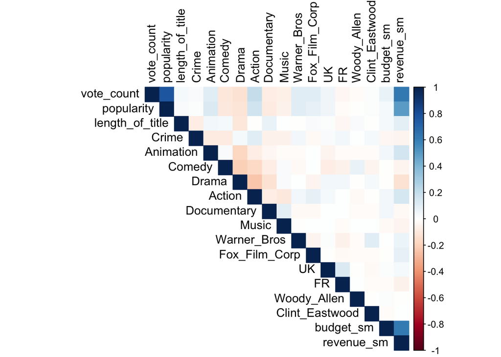

```r
corrplot(corrs, method="color", type="upper", tl.col="black")
```

As we can see from the plot above, popularity and vote count are correlated, vote_count and revenue_sm, revenue_sm and budget_sm, and certain genre combos are also slightly negatively correlated. Since budget_sm and revenue_sm are numbers with a special relationship with one another, we might want to remove one of them.

```r
movies_linear_reg_8 = movies_linear_reg_7 %>% select(-budget_sm)
```

```r
model_8 = lm(vote_average ~ ., data=movies_linear_reg_8)
summary(model_8)
```

```
##
## Call:
## lm(formula = vote_average ~ ., data = movies_linear_reg_8)
##
## Residuals:
##     Min      1Q  Median      3Q     Max
## -6.7110 -0.3598  0.1147  0.5340  5.6553
##
## Coefficients:
##                            Estimate   Std. Error t value
## (Intercept)             5.046655298  0.096354388  52.376
## runtime                 0.010523454  0.000727297  14.469
## vote_count              0.000304374  0.000019983  15.232
## popularity              0.002981686  0.000686096   4.346
## release_date           -0.000052957  0.000003183 -16.638
## length_of_title        -0.004703978  0.001667388  -2.821
## total_spoken_languages  0.052408437  0.015488258   3.384
## Crime                   0.203374973  0.041840554   4.861
## Animation               0.640728875  0.068546205   9.347
## Comedy                  0.132078332  0.031444498   4.200
## Drama                   0.545456865  0.031832635  17.135
## Action                 -0.185206495  0.035678542  -5.191
## Documentary             0.988432437  0.096221066  10.273
## Music                   0.187884035  0.078879743   2.382
## Warner_Bros            -0.157005298  0.062675751  -2.505
## Fox_Film_Corp          -0.132019599  0.066430244  -1.987
## UK                      0.191060946  0.042079938   4.540
## FR                      0.175283803  0.058425879   3.000
## Woody_Allen             0.609661468  0.207237809   2.942
## Clint_Eastwood          0.406377075  0.213206695   1.906
## revenue_sm             -0.000613687  0.000099616  -6.161
##                                    Pr(>|t|)
## (Intercept)            < 0.0000000000000002 ***
## runtime                < 0.0000000000000002 ***
## vote_count             < 0.0000000000000002 ***
## popularity                   0.000014166546 ***
## release_date           < 0.0000000000000002 ***
## length_of_title                    0.004805 **
## total_spoken_languages             0.000721 ***
## Crime                        0.000001207910 ***
## Animation              < 0.0000000000000002 ***
## Comedy                       0.000027144476 ***
## Drama                  < 0.0000000000000002 ***
## Action                       0.000000218053 ***
## Documentary            < 0.0000000000000002 ***
## Music                              0.017263 *
## Warner_Bros                        0.012277 *
## Fox_Film_Corp                      0.046943 *
## UK                           0.000005754977 ***
## FR                                 0.002713 **
## Woody_Allen                        0.003279 **
## Clint_Eastwood                     0.056708 .
## revenue_sm                   0.000000000786 ***
## ---
## Signif. codes:  0 '***' 0.001 '**' 0.01 '*' 0.05 '.' 0.1 ' ' 1
##
## Residual standard error: 0.9431 on 4679 degrees of freedom
##   (3 observations deleted due to missingness)
## Multiple R-squared:  0.3196, Adjusted R-squared:  0.3167
## F-statistic: 109.9 on 20 and 4679 DF,  p-value: < 0.00000000000000022
```

```r
RMSE8 = get.RMSE(model_8$residuals)
RMSE8
```

```
## [1] 0.9409647
```

```r
ARS8 = summary(model_8)$adj.r.squared
ARS8
```

```
## [1] 0.316663
```